# Additional Data Analysis for the ERD experiment

## Basis Summary Statistics

[output not shown]

Data Frame Summary

dat

**Dimensions**: 164 x 6  
**Duplicates**: 0

| **No** | **Variable** | **Stats / Values** | **Freqs (% of Valid)** | **Graph** |
| --- | --- | --- | --- | --- |
| 1 | duration [numeric] | Mean (sd) : 973.8 (622.2) min ≤ med ≤ max: 314 ≤ 818.5 ≤ 5102 IQR (CV) : 440.8 (0.6) | 157 distinct values |  |
| 2 | age [numeric] | Mean (sd) : 38.2 (13.5) min ≤ med ≤ max: 18 ≤ 35 ≤ 77 IQR (CV) : 17.2 (0.4) | 50 distinct values |  |
| 3 | gender [character] | 1. Female 2. Male 3. Non-binary 4. Prefer not to answer | 86 ( 52.4% ) 70 ( 42.7% ) 7 ( 4.3% ) 1 ( 0.6% ) |  |
| 4 | education [ordered, factor] | 1. Less than high school 2. High school graduate 3. Some college 4. 2 year degree 5. 4 year degree 6. Professional degree 7. Master degree 8. Doctorate | 0 ( 0.0% ) 16 ( 9.8% ) 31 ( 18.9% ) 20 ( 12.2% ) 67 ( 40.9% ) 4 ( 2.4% ) 22 ( 13.4% ) 4 ( 2.4% ) |  |
| 5 | income [ordered, factor] | 1. Less than $20,000 2. $20,000 to $39,999 3. $40,000 to $59,999 4. $60,000 to $79,999 5. $80,000 to $99,999 6. $100,000 to $150,000 7. Over $150,000 | 22 ( 13.4% ) 26 ( 15.9% ) 28 ( 17.1% ) 30 ( 18.3% ) 12 ( 7.3% ) 31 ( 18.9% ) 15 ( 9.1% ) |  |
| 6 | condition [character] | 1. Acc 2. PB_LowC 3. PB_RV 4. PushBack 5. Random | 30 ( 18.3% ) 35 ( 21.3% ) 34 ( 20.7% ) 31 ( 18.9% ) 34 ( 20.7% ) |  |

Generated by summarytools 1.0.0 ([R](https://www.r-project.org/) version 4.1.1)  
2023-02-10

## When Switch

The following figures plot when subjects decide to switch for all trails and condition. There are three possible outcomes: 1) subjects switch to an alternative product, 2) subjects receive the initial product, and 3) subjects are forced to switch because the initial product doesn’t arrive before the runway.

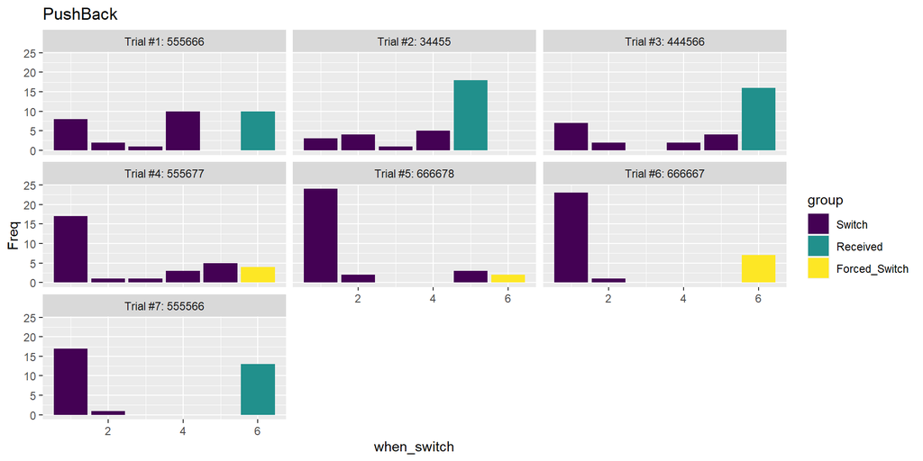

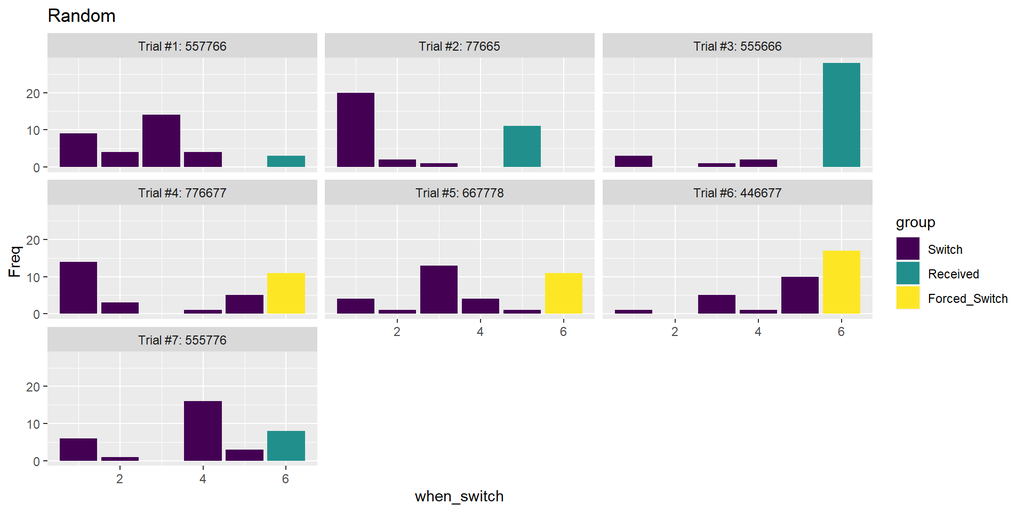

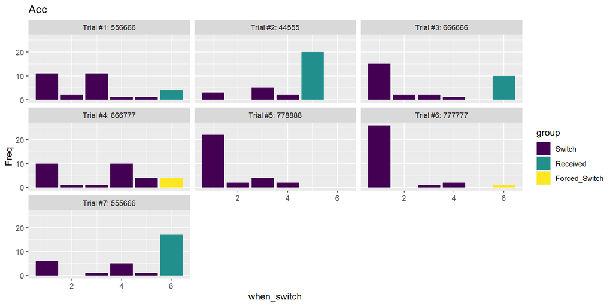

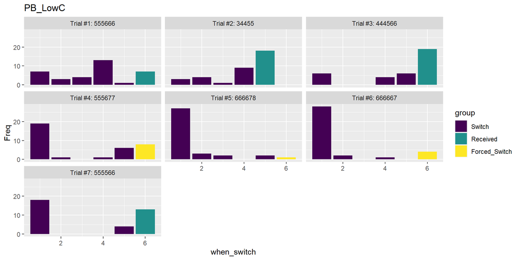

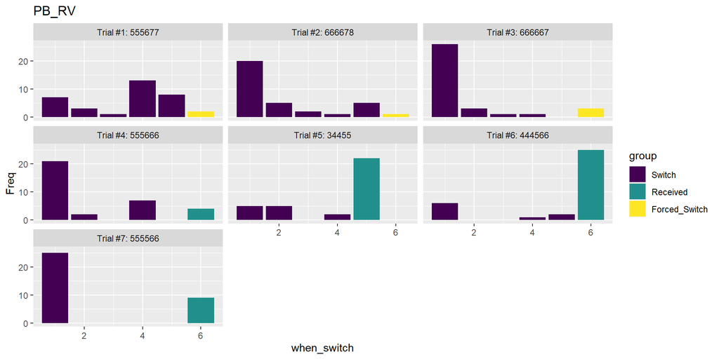

## Subjective ERD

A series of histogram showing the responses on subjective ERD. There are two times that we ask this question: Week 1 and Week 3.

### Week 1 ERD

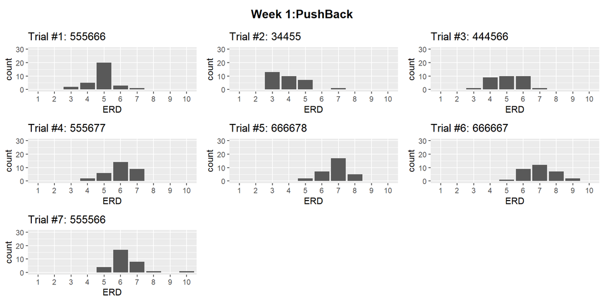

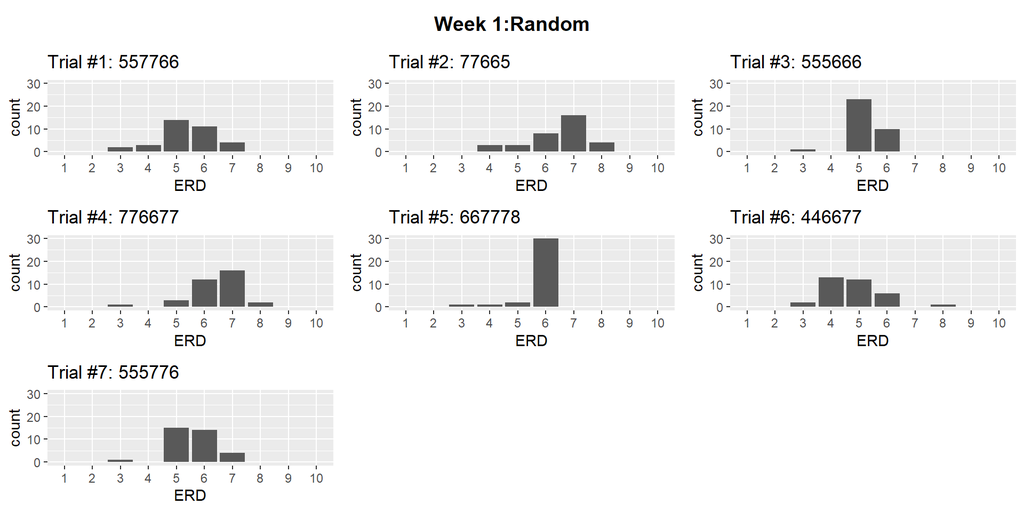

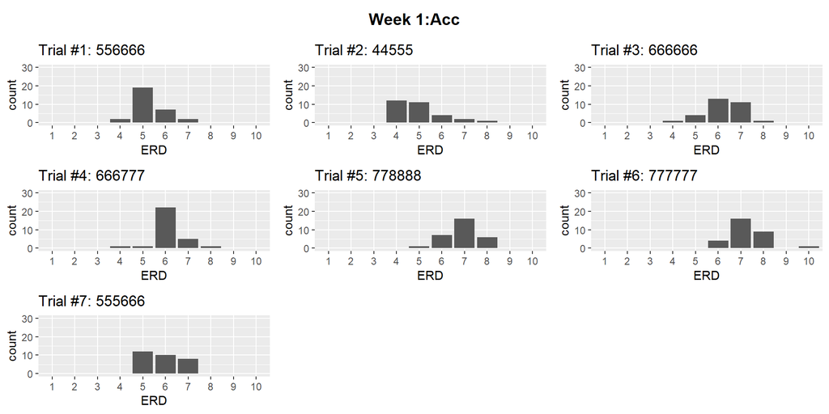

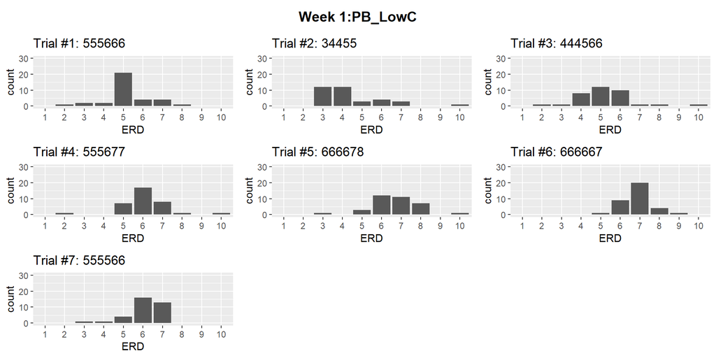

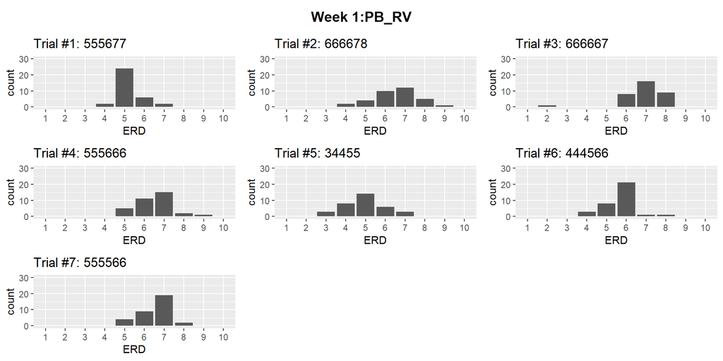

### Week 3 ERD

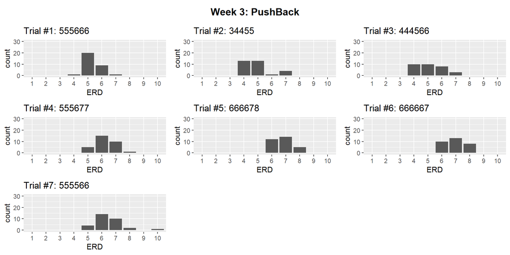

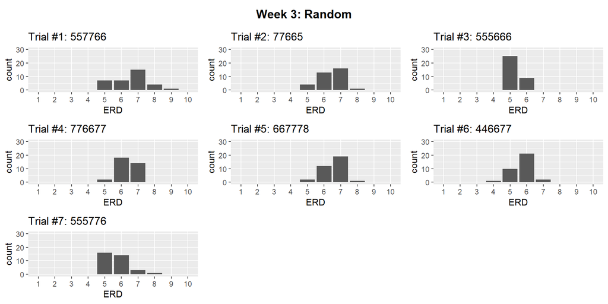

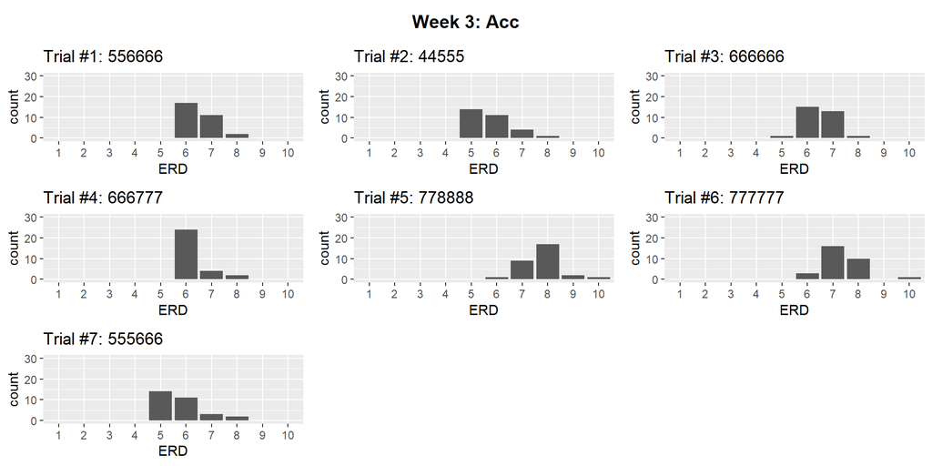

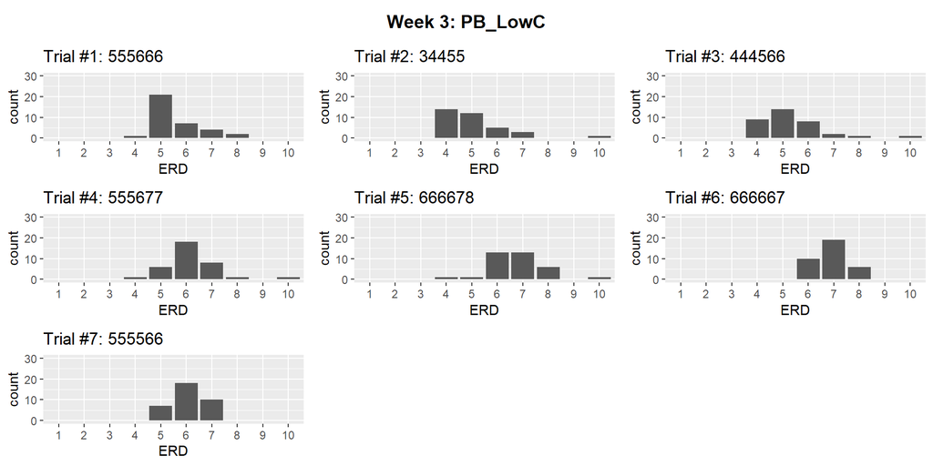

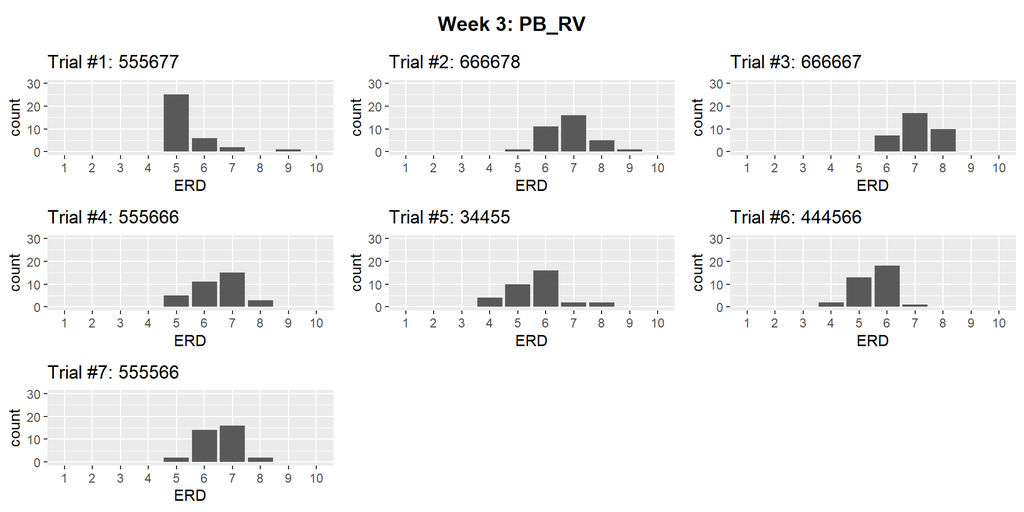

## Probability before the runway.

A series of boxplots summarizing the probability before the runway across 7 trials. There are two times that we ask this question: Week 1 and Week 3.

### Week 1 Prob

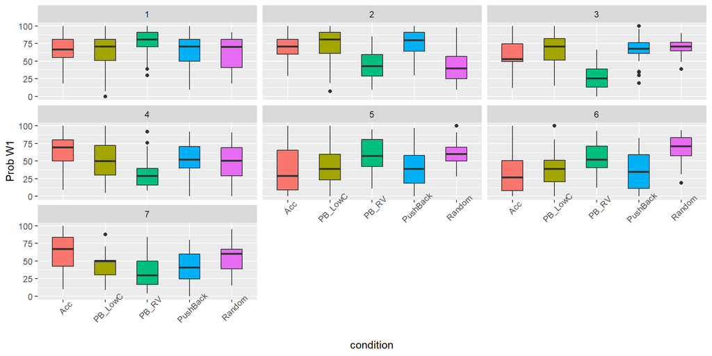

### Week 3 Prob

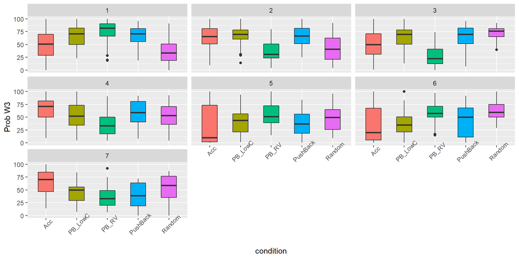

## Condition x Factors

### Condition x Decision T7

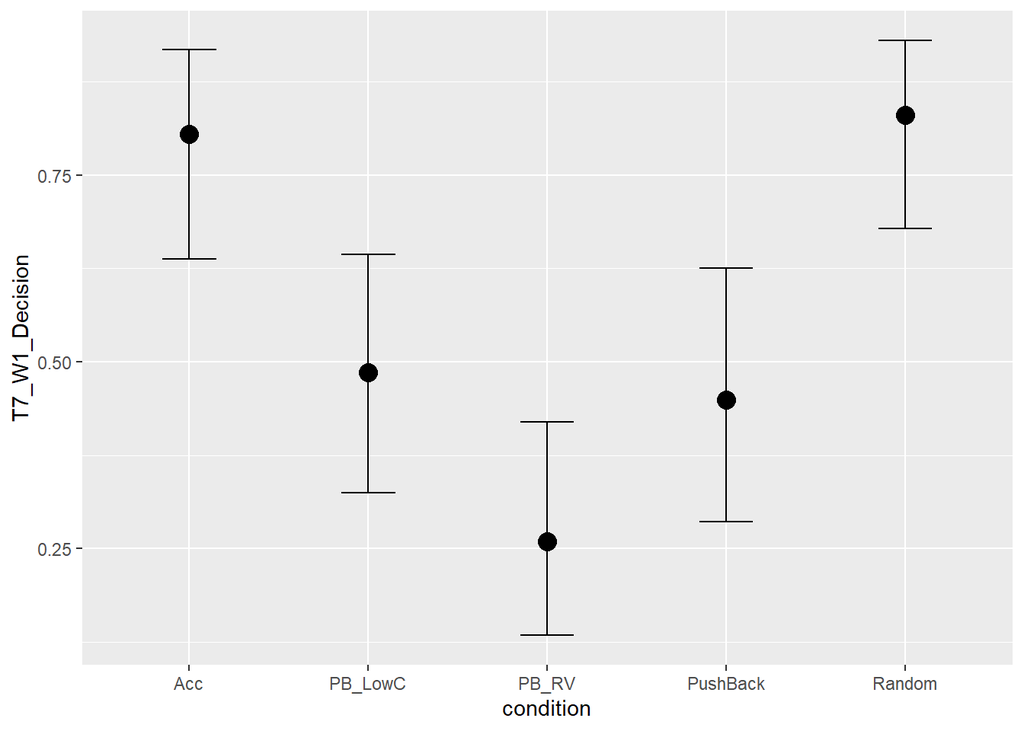

```
##          Hypothesis Estimate Est.Error CI.Lower CI.Upper Star
## 1       Acc-PB_LowC     1.50      0.58     0.39     2.70    *
## 2         Acc-PB_RV     2.50      0.61     1.34     3.70    *
## 3      Acc-Pushback     1.64      0.59     0.51     2.83    *
## 4        Acc-Random    -0.17      0.66    -1.49     1.14
## 5     PB_LowC-PB_RV     1.00      0.51     0.02     2.03    *
## 6  PB_LowC-Pushback     0.14      0.51    -0.86     1.11
## 7    PB_LowC-Random    -1.66      0.58    -2.84    -0.58    *
## 8    PB_RV-Pushback    -0.86      0.55    -1.95     0.19
## 9      PB_RV-Random    -2.67      0.61    -3.94    -1.55    *
## 10  Pushback-Random    -1.81      0.60    -3.00    -0.67    *
```

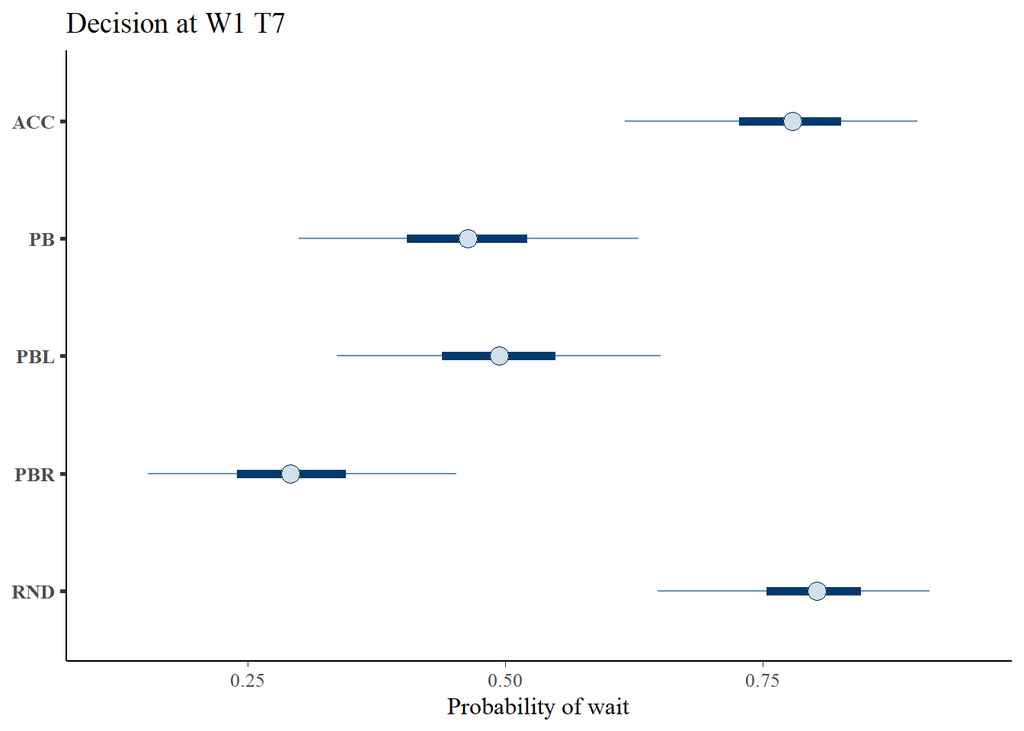

```
##          Hypothesis Estimate Est.Error CI.Lower CI.Upper Star
## 1       Acc-PB_LowC     1.30      0.55     0.27     2.42    *
## 2         Acc-PB_RV     2.18      0.60     1.05     3.41    *
## 3      Acc-Pushback     1.43      0.57     0.38     2.59    *
## 4        Acc-Random    -0.14      0.59    -1.32     1.02
## 5     PB_LowC-PB_RV     0.88      0.50    -0.07     1.91
## 6  PB_LowC-Pushback     0.13      0.47    -0.79     1.06
## 7    PB_LowC-Random    -1.44      0.55    -2.56    -0.41    *
## 8    PB_RV-Pushback    -0.75      0.51    -1.78     0.22
## 9      PB_RV-Random    -2.32      0.60    -3.56    -1.19    *
## 10  Pushback-Random    -1.57      0.57    -2.73    -0.51    *
```

### Condition x Prob T7

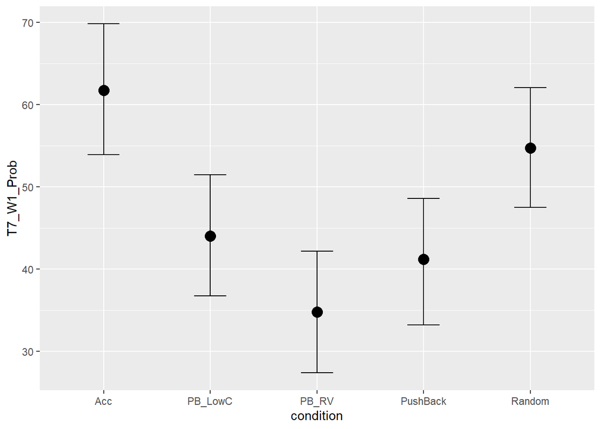

```
##          Hypothesis Estimate Est.Error CI.Lower CI.Upper Star
## 1       Acc-PB_LowC    17.74      5.56     6.80    28.45    *
## 2         Acc-PB_RV    27.01      5.48    16.32    37.84    *
## 3      Acc-Pushback    20.66      5.68     9.64    31.77    *
## 4        Acc-Random     7.03      5.36    -3.56    17.42
## 5     PB_LowC-PB_RV     9.27      5.39    -1.23    19.58
## 6  PB_LowC-Pushback     2.92      5.34    -7.52    13.73
## 7    PB_LowC-Random   -10.71      5.36   -21.56    -0.40    *
## 8    PB_RV-Pushback    -6.35      5.34   -16.56     4.21
## 9      PB_RV-Random   -19.97      5.21   -30.10    -9.54    *
## 10  Pushback-Random   -13.63      5.34   -24.23    -3.14    *
```

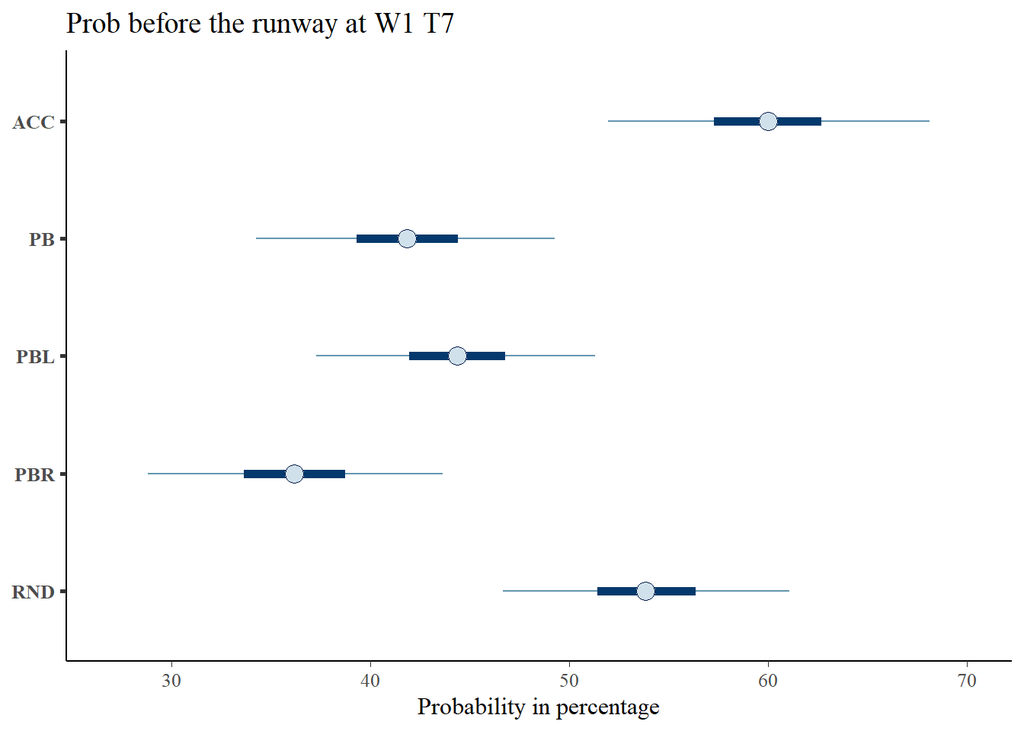

```
##          Hypothesis Estimate Est.Error CI.Lower CI.Upper Star
## 1       Acc-PB_LowC    15.64      5.45     5.15    26.40    *
## 2         Acc-PB_RV    23.82      5.75    12.55    35.01    *
## 3      Acc-Pushback    18.17      5.61     7.28    29.07    *
## 4        Acc-Random     6.13      5.33    -4.00    16.78
## 5     PB_LowC-PB_RV     8.18      5.11    -1.73    18.30
## 6  PB_LowC-Pushback     2.53      5.16    -7.57    12.75
## 7    PB_LowC-Random    -9.51      5.11   -19.56     0.60
## 8    PB_RV-Pushback    -5.65      5.16   -15.79     4.31
## 9      PB_RV-Random   -17.69      5.33   -28.05    -7.11    *
## 10  Pushback-Random   -12.03      5.28   -22.47    -1.62    *
```

### Condition x ERD T7

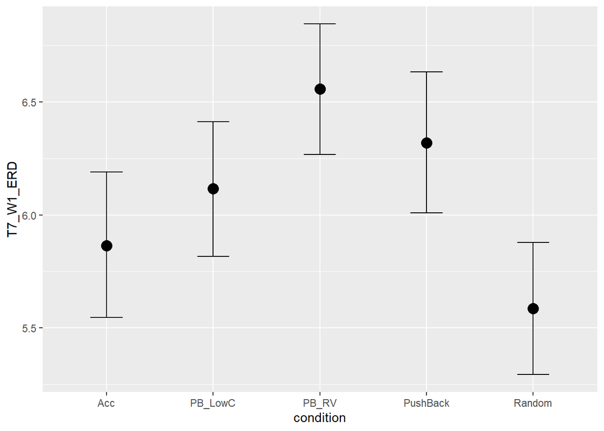

```
##          Hypothesis Estimate Est.Error CI.Lower CI.Upper Star
## 1       Acc-PB_LowC    -0.25      0.22    -0.69     0.19
## 2         Acc-PB_RV    -0.69      0.21    -1.10    -0.28    *
## 3      Acc-Pushback    -0.45      0.23    -0.90     0.00    *
## 4        Acc-Random     0.28      0.21    -0.14     0.68
## 5     PB_LowC-PB_RV    -0.44      0.21    -0.86    -0.03    *
## 6  PB_LowC-Pushback    -0.21      0.21    -0.62     0.21
## 7    PB_LowC-Random     0.53      0.22     0.12     0.96    *
## 8    PB_RV-Pushback     0.24      0.22    -0.20     0.66
## 9      PB_RV-Random     0.97      0.21     0.56     1.38    *
## 10  Pushback-Random     0.73      0.22     0.31     1.17    *
```

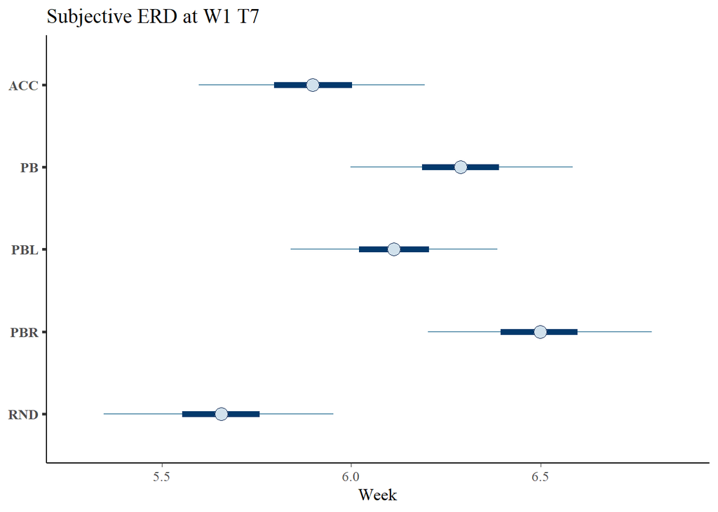

```
##          Hypothesis Estimate Est.Error CI.Lower CI.Upper Star
## 1       Acc-PB_LowC    -0.22      0.20    -0.62     0.17
## 2         Acc-PB_RV    -0.60      0.22    -1.03    -0.18    *
## 3      Acc-Pushback    -0.39      0.22    -0.82     0.02
## 4        Acc-Random     0.24      0.21    -0.15     0.65
## 5     PB_LowC-PB_RV    -0.38      0.20    -0.78     0.00
## 6  PB_LowC-Pushback    -0.18      0.20    -0.58     0.22
## 7    PB_LowC-Random     0.46      0.20     0.06     0.86    *
## 8    PB_RV-Pushback     0.21      0.20    -0.18     0.61
## 9      PB_RV-Random     0.84      0.23     0.40     1.28    *
## 10  Pushback-Random     0.63      0.22     0.21     1.07    *
```

### Condition x Adjusted Performance

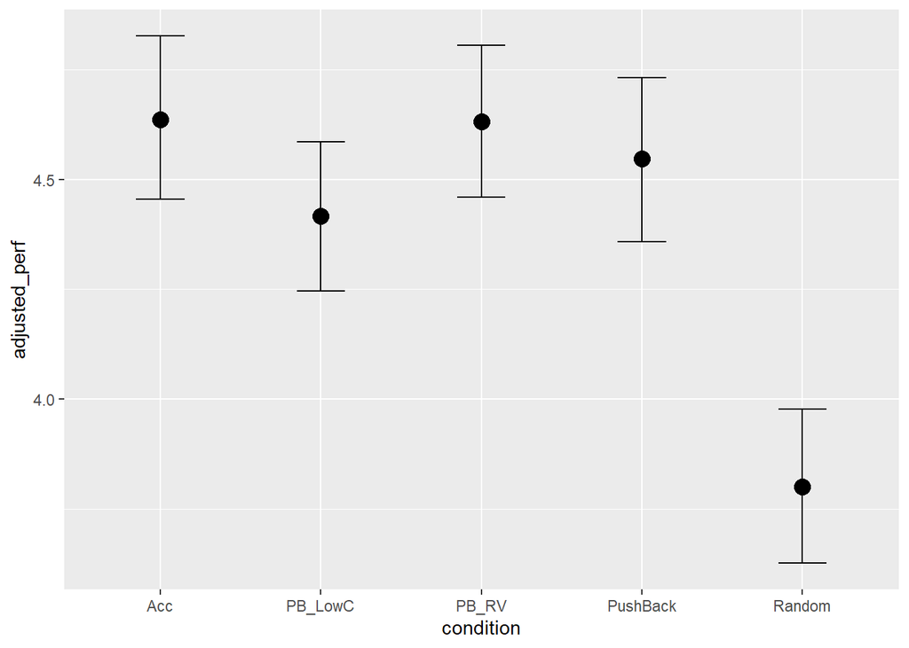

```
##          Hypothesis Estimate Est.Error CI.Lower CI.Upper Star
## 1       Acc-PB_LowC     0.22      0.13    -0.03     0.48
## 2         Acc-PB_RV     0.01      0.13    -0.24     0.26
## 3      Acc-Pushback     0.09      0.13    -0.17     0.36
## 4        Acc-Random     0.84      0.13     0.58     1.08    *
## 5     PB_LowC-PB_RV    -0.22      0.13    -0.47     0.02
## 6  PB_LowC-Pushback    -0.13      0.13    -0.39     0.13
## 7    PB_LowC-Random     0.61      0.13     0.37     0.86    *
## 8    PB_RV-Pushback     0.08      0.13    -0.17     0.35
## 9      PB_RV-Random     0.83      0.13     0.59     1.08    *
## 10  Pushback-Random     0.75      0.13     0.48     1.00    *
```

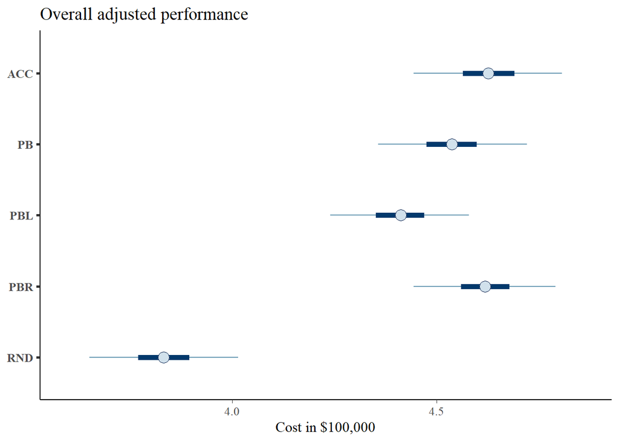

```
##          Hypothesis Estimate Est.Error CI.Lower CI.Upper Star
## 1       Acc-PB_LowC     0.22      0.13    -0.03     0.46
## 2         Acc-PB_RV     0.01      0.13    -0.24     0.25
## 3      Acc-Pushback     0.09      0.13    -0.16     0.34
## 4        Acc-Random     0.79      0.13     0.53     1.05    *
## 5     PB_LowC-PB_RV    -0.21      0.12    -0.45     0.03
## 6  PB_LowC-Pushback    -0.13      0.13    -0.38     0.12
## 7    PB_LowC-Random     0.58      0.13     0.33     0.83    *
## 8    PB_RV-Pushback     0.08      0.13    -0.17     0.33
## 9      PB_RV-Random     0.79      0.13     0.53     1.04    *
## 10  Pushback-Random     0.71      0.13     0.45     0.96    *
```

### Condition x Work Again

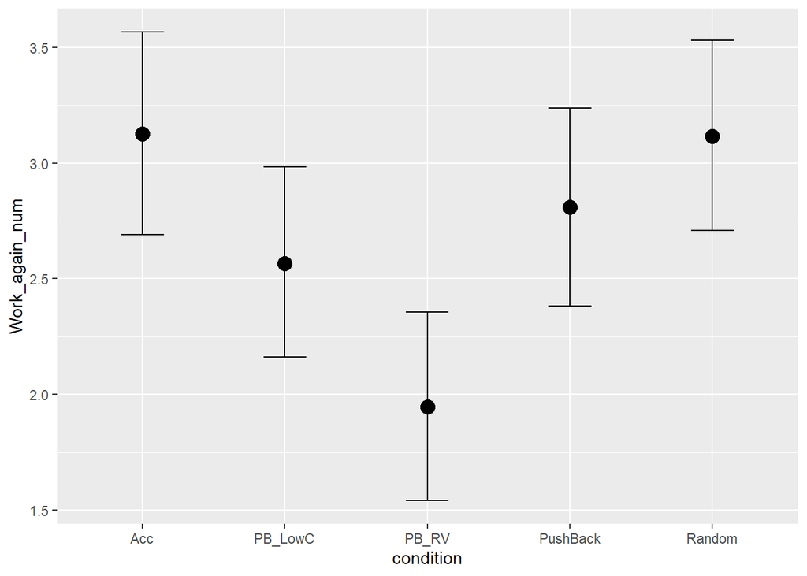

```
##          Hypothesis Estimate Est.Error CI.Lower CI.Upper Star
## 1       Acc-PB_LowC     0.56      0.30    -0.02     1.16
## 2         Acc-PB_RV     1.19      0.29     0.61     1.77    *
## 3      Acc-Pushback     0.32      0.31    -0.28     0.94
## 4        Acc-Random     0.01      0.31    -0.61     0.63
## 5     PB_LowC-PB_RV     0.63      0.29     0.05     1.19    *
## 6  PB_LowC-Pushback    -0.24      0.30    -0.83     0.35
## 7    PB_LowC-Random    -0.55      0.29    -1.14     0.05
## 8    PB_RV-Pushback    -0.86      0.30    -1.44    -0.28    *
## 9      PB_RV-Random    -1.17      0.29    -1.74    -0.59    *
## 10  Pushback-Random    -0.31      0.31    -0.90     0.29
```

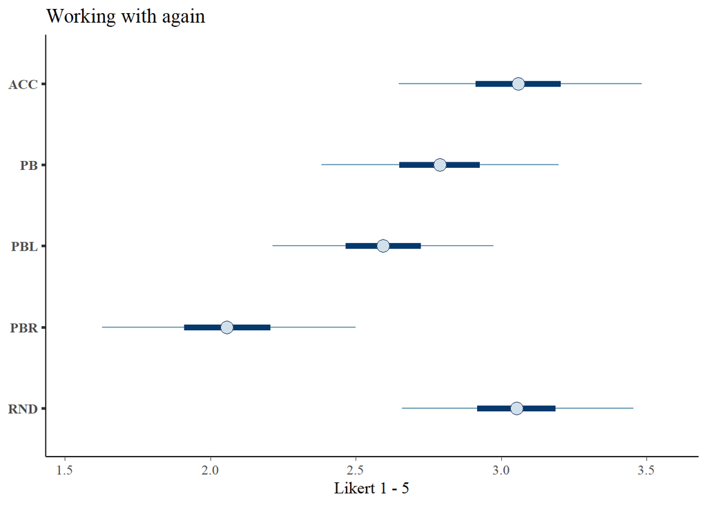

```
##          Hypothesis Estimate Est.Error CI.Lower CI.Upper Star
## 1       Acc-PB_LowC     0.47      0.28    -0.09     1.03
## 2         Acc-PB_RV     1.00      0.32     0.36     1.62    *
## 3      Acc-Pushback     0.27      0.29    -0.29     0.86
## 4        Acc-Random     0.01      0.28    -0.54     0.57
## 5     PB_LowC-PB_RV     0.54      0.28    -0.01     1.11
## 6  PB_LowC-Pushback    -0.19      0.28    -0.75     0.35
## 7    PB_LowC-Random    -0.46      0.28    -1.02     0.09
## 8    PB_RV-Pushback    -0.73      0.30    -1.32    -0.14    *
## 9      PB_RV-Random    -0.99      0.31    -1.60    -0.37    *
## 10  Pushback-Random    -0.26      0.28    -0.83     0.29
```

### Condition x T6 Trust

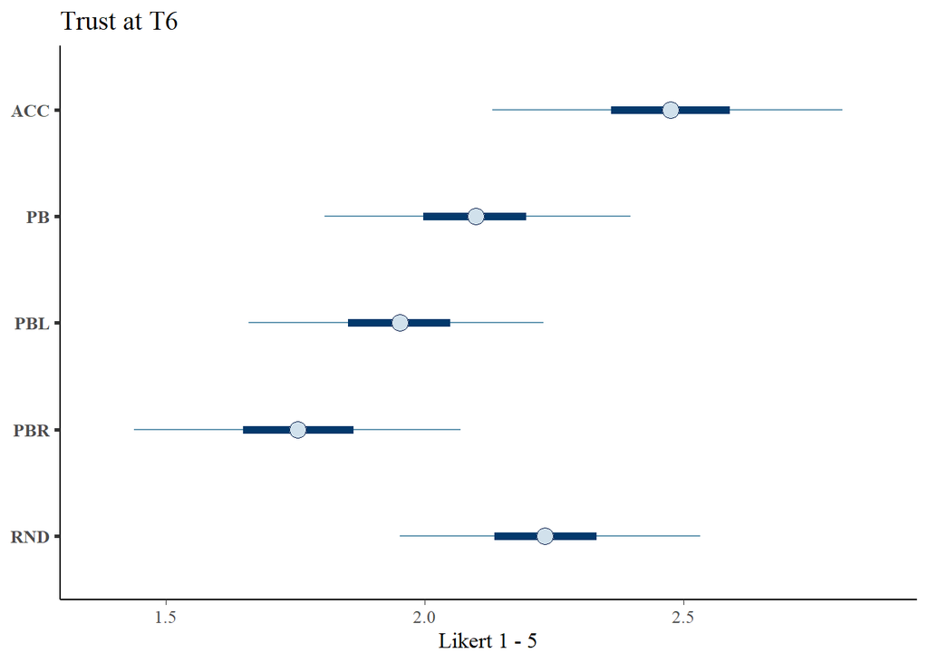

```
##          Hypothesis Estimate Est.Error CI.Lower CI.Upper Star
## 1       Acc-PB_LowC     0.52      0.23     0.08     0.97    *
## 2         Acc-PB_RV     0.72      0.25     0.20     1.20    *
## 3      Acc-Pushback     0.38      0.22    -0.04     0.82
## 4        Acc-Random     0.24      0.21    -0.16     0.66
## 5     PB_LowC-PB_RV     0.19      0.20    -0.20     0.60
## 6  PB_LowC-Pushback    -0.15      0.21    -0.56     0.25
## 7    PB_LowC-Random    -0.28      0.21    -0.70     0.11
## 8    PB_RV-Pushback    -0.34      0.21    -0.78     0.07
## 9      PB_RV-Random    -0.48      0.22    -0.91    -0.05    *
## 10  Pushback-Random    -0.14      0.21    -0.56     0.26
```

### Condition x T6 Competent

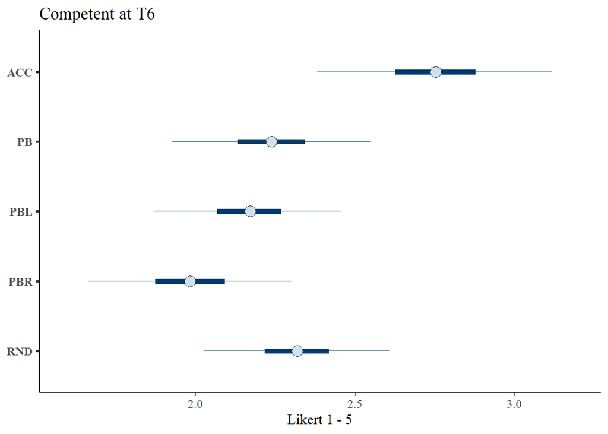

```
##          Hypothesis Estimate Est.Error CI.Lower CI.Upper Star
## 1       Acc-PB_LowC     0.58      0.24     0.10     1.06    *
## 2         Acc-PB_RV     0.77      0.27     0.22     1.28    *
## 3      Acc-Pushback     0.51      0.24     0.05     1.00    *
## 4        Acc-Random     0.43      0.23     0.00     0.90
## 5     PB_LowC-PB_RV     0.19      0.21    -0.21     0.60
## 6  PB_LowC-Pushback    -0.07      0.21    -0.49     0.35
## 7    PB_LowC-Random    -0.15      0.21    -0.56     0.25
## 8    PB_RV-Pushback    -0.25      0.22    -0.70     0.16
## 9      PB_RV-Random    -0.33      0.22    -0.77     0.07
## 10  Pushback-Random    -0.08      0.21    -0.51     0.34
```

### Condition x T6 Benevolent

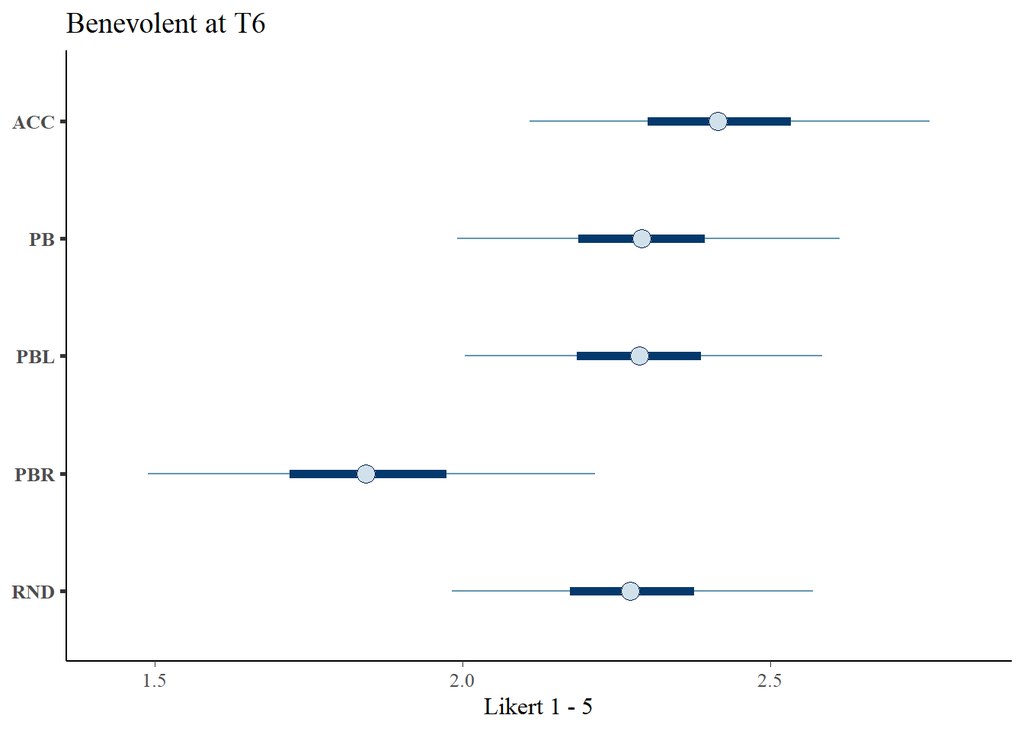

```
##          Hypothesis Estimate Est.Error CI.Lower CI.Upper Star
## 1       Acc-PB_LowC     0.13      0.21    -0.27     0.59
## 2         Acc-PB_RV     0.57      0.27     0.03     1.12    *
## 3      Acc-Pushback     0.13      0.21    -0.28     0.57
## 4        Acc-Random     0.14      0.21    -0.26     0.58
## 5     PB_LowC-PB_RV     0.44      0.24     0.00     0.92
## 6  PB_LowC-Pushback    -0.01      0.21    -0.41     0.41
## 7    PB_LowC-Random     0.01      0.20    -0.38     0.41
## 8    PB_RV-Pushback    -0.45      0.25    -0.94     0.01
## 9      PB_RV-Random    -0.43      0.24    -0.91     0.01
## 10  Pushback-Random     0.02      0.21    -0.39     0.43
```

### Condition x T6 Predictable

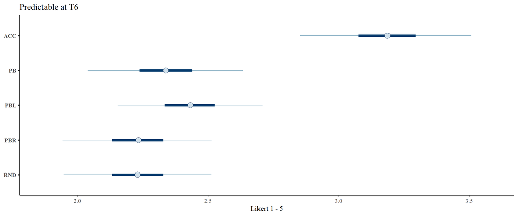

```
##          Hypothesis Estimate Est.Error CI.Lower CI.Upper Star
## 1       Acc-PB_LowC     0.75      0.22     0.34     1.18    *
## 2         Acc-PB_RV     0.95      0.23     0.51     1.39    *
## 3      Acc-Pushback     0.85      0.23     0.40     1.30    *
## 4        Acc-Random     0.96      0.22     0.51     1.39    *
## 5     PB_LowC-PB_RV     0.20      0.20    -0.19     0.59
## 6  PB_LowC-Pushback     0.09      0.20    -0.31     0.50
## 7    PB_LowC-Random     0.20      0.20    -0.19     0.59
## 8    PB_RV-Pushback    -0.11      0.21    -0.51     0.30
## 9      PB_RV-Random     0.00      0.20    -0.40     0.41
## 10  Pushback-Random     0.11      0.20    -0.30     0.51
```

### Figure for the main paper

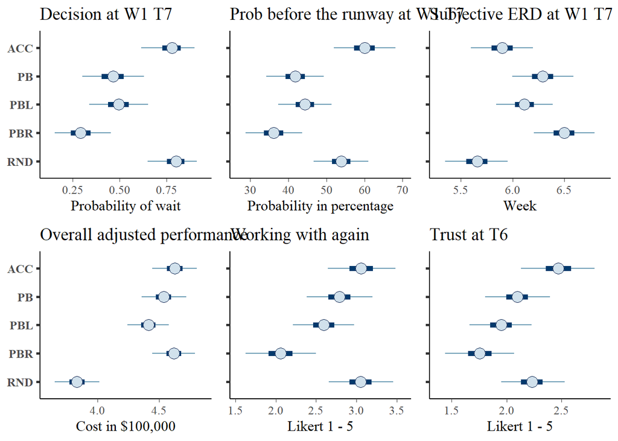